# Mammal data - Mediterranean Desert Transition Zone

Talia Gabay & Ron Chen

2025-11-11

```r
P <- P_byplot[grepl("Mediterranean Desert Transition Zone",Unit),][order(Cycle_number,Site)][,Site:=factor(Site)]
```

## Mediterranean Desert Transition Zone - Richness by camera

Monitoring started in 2014 (5 monitoring cycles), Each site as two types of plots - near or far from Settlements. There are 5 sites total - Beit Yatir, Har Amasa, Lahav, Lehavim, Mirsham Each has 5 sampling points except for Mirsham which is missing samples from the first year (2014)

Let’s first validate the data:

```r
#include rare species in analysis
P.anal <- copy(P) # set a fixed variable name for analysis, if want to switch between data WITH rare #species and data WITHOUT rare species then only change once here
#Validate factors and levels
P.anal$Settlements <- as.factor(P.anal$Settlements)
print("Settlements has 2 levels")
```

```
## [1] "Settlements has 2 levels"
```

```r
print(levels(P.anal$Settlements))
```

```
## [1] "Far"  "Near"
```

```r
P.anal$Site <- as.factor(P.anal$Site)
print("Site has 5 levels")
```

```
## [1] "Site has 5 levels"
```

```r
print(levels(P.anal$Site))
```

```
## [1] "Beit Yatir" "Har Amasa"  "Lahav"      "Lehavim"    "Mirsham"
```

```r
P.anal$Transect <- as.factor(P.anal$Transect)
print("Transect has 10 levels")
```

```
## [1] "Transect has 10 levels"
```

```r
print(levels(P.anal$Transect))
```

```
##  [1] "Beit Yatir Far"  "Beit Yatir Near" "Har Amasa Far"   "Har Amasa Near"
##  [5] "Lahav Far"       "Lahav Near"      "Lehavim Far"     "Lehavim Near"
##  [9] "Mirsham Far"     "Mirsham Near"
```

```r
P.anal$Transect_with_date <- as.factor(P.anal$Transect_with_date)
print("Transect with date has 49 levels - Missing data for Mirsham near in 2014")
```

```
## [1] "Transect with date has 49 levels - Missing data for Mirsham near in 2014"
```

```r
print(levels(P.anal$Transect_with_date))
```

```
##  [1] "Beit Yatir Far_03_01_2017"  "Beit Yatir Far_13_07_2014"
##  [3] "Beit Yatir Far_16_11_2020"  "Beit Yatir Far_20_11_2018"
##  [5] "Beit Yatir Far_26_02_2023"  "Beit Yatir Near_03_01_2017"
##  [7] "Beit Yatir Near_13_07_2014" "Beit Yatir Near_16_11_2020"
##  [9] "Beit Yatir Near_20_11_2018" "Beit Yatir Near_26_02_2023"
## [11] "Har Amasa Far_16_11_2020"   "Har Amasa Far_17_07_2014"
## [13] "Har Amasa Far_22_12_2016"   "Har Amasa Far_24_11_2018"
## [15] "Har Amasa Far_24_11_2022"   "Har Amasa Near_16_11_2020"
## [17] "Har Amasa Near_17_07_2014"  "Har Amasa Near_22_12_2016"
## [19] "Har Amasa Near_24_11_2018"  "Har Amasa Near_24_11_2022"
## [21] "Lahav Far_13_11_2022"       "Lahav Far_20_11_2016"
## [23] "Lahav Far_25_08_2020"       "Lahav Far_30_07_2014"
## [25] "Lahav Far_30_10_2018"       "Lahav Near_13_11_2022"
## [27] "Lahav Near_20_11_2016"      "Lahav Near_25_08_2020"
## [29] "Lahav Near_30_07_2014"      "Lahav Near_30_10_2018"
## [31] "Lehavim Far_05_09_2020"     "Lehavim Far_05_11_2016"
## [33] "Lehavim Far_08_12_2018"     "Lehavim Far_27_11_2022"
## [35] "Lehavim Far_31_07_2014"     "Lehavim Near_05_09_2020"
## [37] "Lehavim Near_05_11_2016"    "Lehavim Near_08_12_2018"
## [39] "Lehavim Near_27_11_2022"    "Lehavim Near_31_07_2014"
## [41] "Mirsham Far_03_12_2016"     "Mirsham Far_04_08_2014"
## [43] "Mirsham Far_13_08_2020"     "Mirsham Far_24_02_2023"
## [45] "Mirsham Far_29_10_2018"     "Mirsham Near_03_12_2016"
## [47] "Mirsham Near_13_08_2020"    "Mirsham Near_24_02_2023"
## [49] "Mirsham Near_29_10_2018"
```

```r
#distance.rescaled <- scale(all.mammal.abundances$Distance)
#write.csv(distance.rescaled, file = "Distance_rescaled.csv")
```

```r
print("RICHNESS WITH RARE SPECIES")
```

```
## [1] "RICHNESS WITH RARE SPECIES"
```

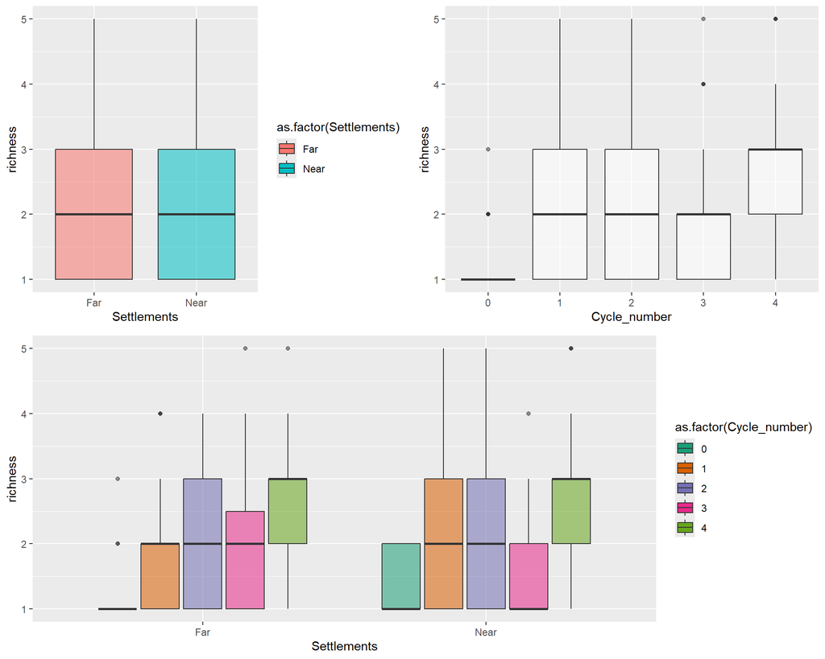

```r
plot_alpha_diversity(P, x_val = "Settlements", y_val = "richness", ylab_val = "richness", xlab_val = "Settlements", fill_val = "Settlements")
```

```r
col_names <- c("Cycle_number",  "Deployment.id_new",    "Unit", "Subunit",  "Site", "Settlements",  "Distance_rescaled",    "Lon",  "Lat", "year", "rescaled_Time.Diff", "sinus_Monitoring.Time.Diff", "cosinus_Monitoring.Time.Diff", "Transect", "Transect_with_date")

abu_by_spp.MDtransitionalzone <- all.mammal.abundances[grepl("Mediterranean Desert Transition Zone",Unit),]
write.csv(abu_by_spp.MDtransitionalzone, "../output/sfar/data_table_MD_trans_zone.csv")
spp <- abu_by_spp.MDtransitionalzone[,27:40]
#spp <- abu_by_spp.MDtransitionalzone[,25:38]
# filter out species with zero counts
print(colSums(spp))
```

```
##      Canis aureus       Canis lupus     Capra nubiana Dama mesopotamica
##               467                 0                 0                 0
##    Equus hemionus    Gazella dorcas   Gazella gazella     Hyaena hyaena
##                 0                 0               940                22
##    Hystrix indica    Lepus capensis       Meles meles     Oryx leucoryx
##                97               181                39                 0
##        Sus scrofa     Vulpes vulpes
##                 0               708
```

```
## Overlapping points were shifted along the y-axis to make them visible.
```

```
##
##  PIPING TO 2nd MVFACTOR
```

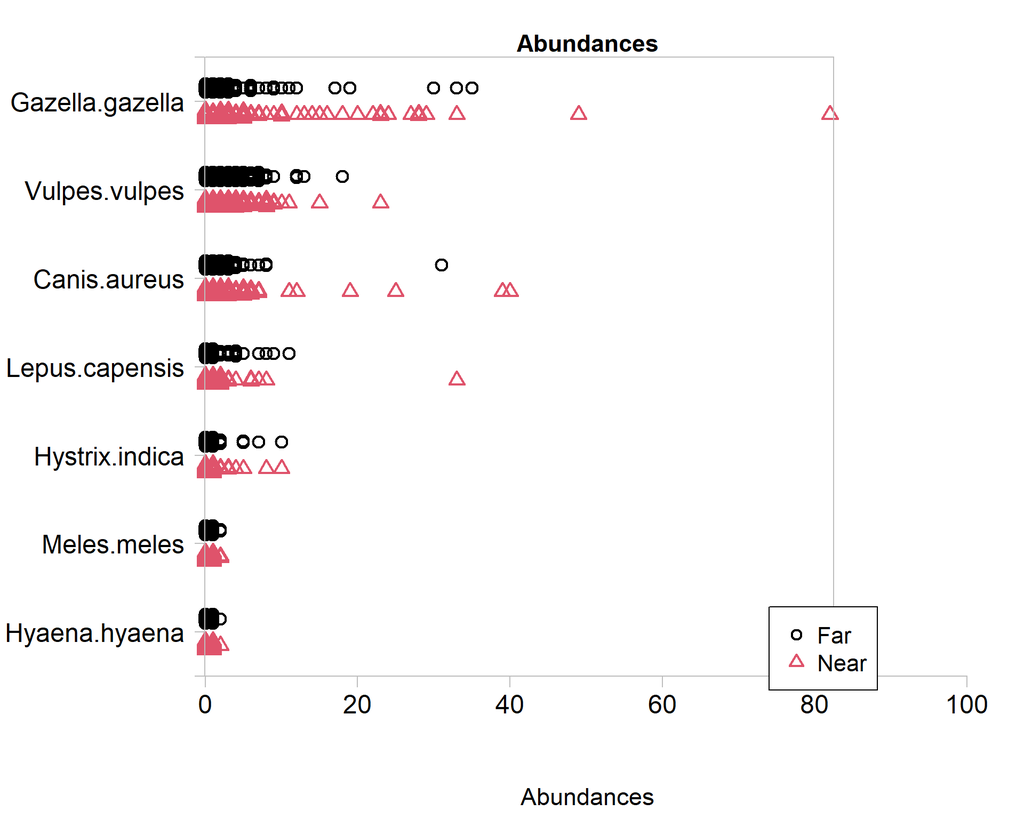

```r
spp <- spp[,.SD,.SDcols = colSums(spp)>0]
spp <- mvabund(spp)

plot(spp ~ P.anal$Settlements, overall.main="raw abundances", transformation = "no")
```

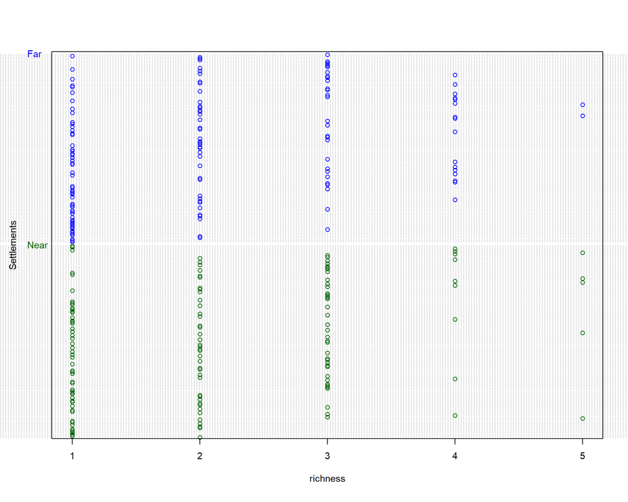

```r
my_cols <- c("blue", "darkgreen")
dotchart(P.anal$richness, ylab = "Settlements",
         groups = P.anal$Settlements, gcolor = my_cols,
         color = my_cols[P.anal$Settlements],
         cex = 0.9,  pch = 1, xlab = "richness")
```

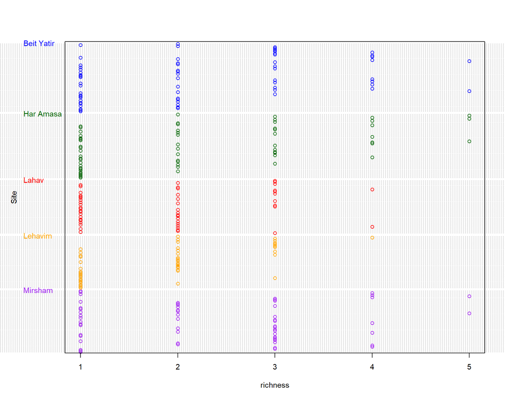

```r
my_cols <- c("blue", "darkgreen", "red", "orange", "purple")
dotchart(P.anal$richness, ylab = "Site",
         groups = P.anal$Site, gcolor = my_cols,
         color = my_cols[P.anal$Site],
         cex = 0.9,  pch = 1, xlab = "richness")
```

```r
kable(summary(P.anal[,.(richness, abundance, rescaled_Time.Diff, cosinus_Monitoring.Time.Diff, sinus_Monitoring.Time.Diff, Site, Transect, Transect_with_date, Distance_rescaled)]))
```

|  | richness | abundance | rescaled_Time.Diff | cosinus_Monitoring.Time.Diff | sinus_Monitoring.Time.Diff | Site | Transect | Transect_with_date | Distance_rescaled |
| --- | --- | --- | --- | --- | --- | --- | --- | --- | --- |
|  | Min. :1.000 | Min. : 1.000 | Min. :-1.1972 | Min. :-0.99996 | Min. :-0.9454 | Beit Yatir:64 | Beit Yatir Far :34 | Mirsham Near_03_12_2016 : 10 | Min. :-0.9136 |
|  | 1st Qu.:1.000 | 1st Qu.: 2.000 | 1st Qu.:-0.4256 | 1st Qu.:-0.36729 | 1st Qu.:-0.8818 | Har Amasa :60 | Har Amasa Near :31 | Beit Yatir Far_26_02_2023: 9 | 1st Qu.:-0.6122 |
|  | Median :2.000 | Median : 5.000 | Median : 0.1810 | Median :-0.06634 | Median : 0.3959 | Lahav :50 | Mirsham Near :31 | Har Amasa Near_24_11_2022: 9 | Median :-0.4099 |
|  | Mean :2.114 | Mean : 8.733 | Mean : 0.3403 | Mean : 0.02591 | Mean : 0.1136 | Lehavim :49 | Beit Yatir Near:30 | Mirsham Near_24_02_2023 : 9 | Mean :-0.2132 |
|  | 3rd Qu.:3.000 | 3rd Qu.:10.000 | 3rd Qu.: 1.4339 | 3rd Qu.: 0.58421 | 3rd Qu.: 0.9333 | Mirsham :58 | Har Amasa Far :29 | Mirsham Near_29_10_2018 : 9 | 3rd Qu.: 0.1560 |
|  | Max. :5.000 | Max. :89.000 | Max. : 1.5246 | Max. : 0.99984 | Max. : 0.9978 | NA | Lahav Near :27 | Beit Yatir Far_03_01_2017: 8 | Max. : 1.2141 |
|  | NA | NA | NA | NA | NA | NA | (Other) :99 | (Other) :227 | NA |

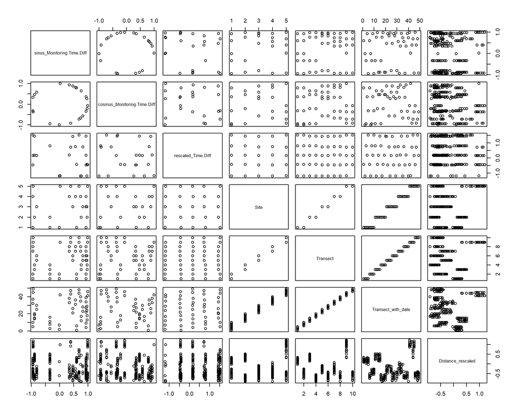

```r
pairs(P.anal[,lapply(X = .SD,FUN = as.numeric),.SDcols=c("sinus_Monitoring.Time.Diff", "cosinus_Monitoring.Time.Diff","rescaled_Time.Diff","Site","Transect", "Transect_with_date", "Distance_rescaled")])
```

```r
kable(cor(P.anal[,lapply(X = .SD,FUN = as.numeric),.SDcols=c("sinus_Monitoring.Time.Diff", "cosinus_Monitoring.Time.Diff","rescaled_Time.Diff","Site","Transect", "Transect_with_date", "Distance_rescaled")]))
```

|  | sinus_Monitoring.Time.Diff | cosinus_Monitoring.Time.Diff | rescaled_Time.Diff | Site | Transect | Transect_with_date | Distance_rescaled |
| --- | --- | --- | --- | --- | --- | --- | --- |
| sinus_Monitoring.Time.Diff | 1.0000000 | 0.0471620 | -0.2553691 | 0.2151478 | 0.2149245 | 0.1688694 | -0.0721399 |
| cosinus_Monitoring.Time.Diff | 0.0471620 | 1.0000000 | -0.1553489 | -0.0579959 | -0.0577145 | -0.0685072 | -0.1504014 |
| rescaled_Time.Diff | -0.2553691 | -0.1553489 | 1.0000000 | -0.0123308 | -0.0043925 | 0.0254338 | -0.0474549 |
| Site | 0.2151478 | -0.0579959 | -0.0123308 | 1.0000000 | 0.9857080 | 0.9813614 | 0.0812471 |
| Transect | 0.2149245 | -0.0577145 | -0.0043925 | 0.9857080 | 1.0000000 | 0.9949286 | -0.0511837 |
| Transect_with_date | 0.1688694 | -0.0685072 | 0.0254338 | 0.9813614 | 0.9949286 | 1.0000000 | -0.0450595 |
| Distance_rescaled | -0.0721399 | -0.1504014 | -0.0474549 | 0.0812471 | -0.0511837 | -0.0450595 | 1.0000000 |

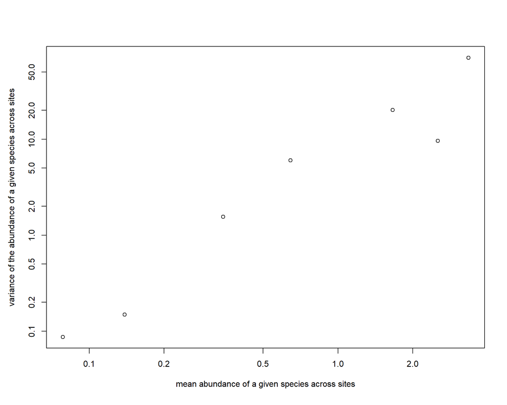

```r
meanvar.plot(spp, xlab = "mean abundance of a given species across sites", ylab = "variance of the abundance of a given species across sites")
```

```r
mdl_r.poiss.int <- glm(data = P.anal, formula = richness ~ Distance_rescaled * rescaled_Time.Diff + cosinus_Monitoring.Time.Diff + sinus_Monitoring.Time.Diff + Site + Transect_with_date, family = poisson)
od <- mdl_r.poiss.int$deviance/mdl_r.poiss.int$df.residual
print("Estimating overdispersion parameter phi: (Res. Dev.)/(n-p) where n=number of observations; p=number of parameters in the model.")
```

```
## [1] "Estimating overdispersion parameter phi: (Res. Dev.)/(n-p) where n=number of observations; p=number of parameters in the model."
```

```r
print(paste0('od = ',od))
```

```
## [1] "od = 0.401906034280057"
```

Overdispersion parameter is <1 (underdispersion) and therefore will use Poisson

```r
m0 <- glm(data = P.anal, formula =  richness ~ Distance_rescaled * rescaled_Time.Diff + cosinus_Monitoring.Time.Diff + sinus_Monitoring.Time.Diff, family = poisson)

me0transectwithdate <- glmer(data = P.anal, formula =   richness ~ Distance_rescaled * rescaled_Time.Diff + cosinus_Monitoring.Time.Diff + sinus_Monitoring.Time.Diff +  (1|Transect_with_date), family = poisson, verbose = 1)
```

[output not shown]

```
## boundary (singular) fit: see help('isSingular')
```

```r
me0transect <- glmer(data = P.anal, formula =   richness ~ Distance_rescaled * rescaled_Time.Diff + cosinus_Monitoring.Time.Diff + sinus_Monitoring.Time.Diff +  (1|Transect), family = poisson, verbose = 1)
```

[output not shown]

```
## boundary (singular) fit: see help('isSingular')
```

```r
me0site <- glmer(data = P.anal, formula =   richness ~ Distance_rescaled * rescaled_Time.Diff + cosinus_Monitoring.Time.Diff + sinus_Monitoring.Time.Diff +  (1|Site), family = poisson, verbose = 1)
```

[output not shown]

```
## boundary (singular) fit: see help('isSingular')
```

All GLMERs result in singular fit, will use regular GLM:

```r
m1 <- step(m0)
```

```
## Start:  AIC=862.24
## richness ~ Distance_rescaled * rescaled_Time.Diff + cosinus_Monitoring.Time.Diff +
##     sinus_Monitoring.Time.Diff
##
##                                        Df Deviance    AIC
## - Distance_rescaled:rescaled_Time.Diff  1   132.90 860.24
## - cosinus_Monitoring.Time.Diff          1   132.95 860.29
## - sinus_Monitoring.Time.Diff            1   132.98 860.32
## <none>                                      132.90 862.24
##
## Step:  AIC=860.24
## richness ~ Distance_rescaled + rescaled_Time.Diff + cosinus_Monitoring.Time.Diff +
##     sinus_Monitoring.Time.Diff
##
##                                Df Deviance    AIC
## - cosinus_Monitoring.Time.Diff  1   132.95 858.29
## - sinus_Monitoring.Time.Diff    1   132.98 858.32
## - Distance_rescaled             1   133.75 859.09
## <none>                              132.90 860.24
## - rescaled_Time.Diff            1   150.64 875.98
##
## Step:  AIC=858.29
## richness ~ Distance_rescaled + rescaled_Time.Diff + sinus_Monitoring.Time.Diff
##
##                              Df Deviance    AIC
## - sinus_Monitoring.Time.Diff  1   133.03 856.37
## - Distance_rescaled           1   133.75 857.09
## <none>                            132.95 858.29
## - rescaled_Time.Diff          1   150.93 874.27
##
## Step:  AIC=856.37
## richness ~ Distance_rescaled + rescaled_Time.Diff
##
##                      Df Deviance    AIC
## - Distance_rescaled   1   133.79 855.13
## <none>                    133.03 856.37
## - rescaled_Time.Diff  1   151.56 872.90
##
## Step:  AIC=855.13
## richness ~ rescaled_Time.Diff
##
##                      Df Deviance    AIC
## <none>                    133.79 855.13
## - rescaled_Time.Diff  1   151.99 871.32
```

```r
# m1 <- glmer(data = P.anal, formula = richness ~ Distance_rescaled * rescaled_Time.Diff + cosinus_Monitoring.Time.Diff + (1|Transect_with_date), family = poisson)
# drop1(m1)
```

```r
# m2 <- glmer(data = P.anal, formula = richness ~ Distance_rescaled * rescaled_Time.Diff + (1|Transect_with_date), family = poisson)
# drop1(m2)
```

Final model includes time difference

```r
summ(m1, exp = TRUE, digits=3)
```

| Observations | 281 |
| --- | --- |
| Dependent variable | richness |
| Type | Generalized linear model |
| Family | poisson |
| Link | log |

| χ²(1) | 18.194 |
| --- | --- |
| Pseudo-R² (Cragg-Uhler) | 0.066 |
| Pseudo-R² (McFadden) | 0.021 |
| AIC | 855.130 |
| BIC | 862.407 |

|  | exp(Est.) | 2.5% | 97.5% | z val. | p |
| --- | --- | --- | --- | --- | --- |
| (Intercept) | 1.944 | 1.772 | 2.133 | 14.084 | 0.000 |
| rescaled_Time.Diff | 1.222 | 1.113 | 1.340 | 4.235 | 0.000 |

Standard errors: MLE

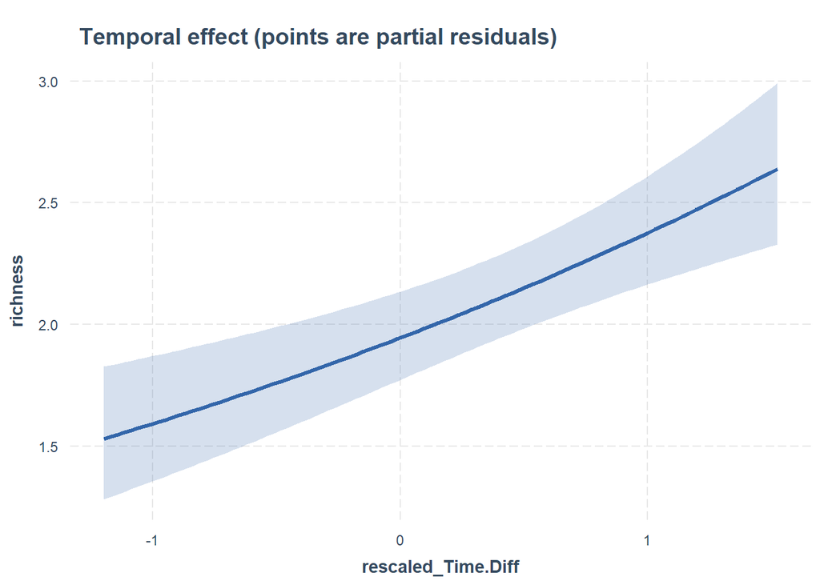

```r
effect_plot(model = m1, data=P.anal, pred = rescaled_Time.Diff, interval = T, plot.points = F, jitter = c(0.1,0), point.size = 3, cat.pred.point.size = 4, partial.residuals = F, colors = "Qual1", main.title = "Temporal effect (points are partial residuals)")
```

```r
#m_coef <- coef(m2)
#P.anal$Cycle_number <- as.numeric(P.anal$Cycle_number)
#plot(P.anal$Cycle_number,
 #    exp(m_coef["rescaled_Time.Diff"]*P.anal$rescaled_Time.Diff),
 #xlab = "Cycle number", ylab = "contribution to richness")
```

Time difference significantly affects species richness

#### Community analysis using package MVabund

Table of abundances per species by camera ID

```r
abundance_and_cameras <- as.data.table(abu_by_spp.MDtransitionalzone[,c(5,27:40)])
dim(abundance_and_cameras)
```

```
## [1] 281  15
```

```r
canisau <- abundance_and_cameras[,2] > 0
sum(canisau)
```

```
## [1] 125
```

```r
canislup <- abundance_and_cameras[,3] > 0
sum(canislup)
```

```
## [1] 0
```

```r
capra <- abundance_and_cameras[,4] > 0
sum(capra)
```

```
## [1] 0
```

```r
Doma <- abundance_and_cameras[,5] > 0
sum(Doma)
```

```
## [1] 0
```

```r
Equus <- abundance_and_cameras[,6] > 0
sum(Equus)
```

```
## [1] 0
```

```r
Gazellador <- abundance_and_cameras[,7] > 0
sum(Gazellador)
```

```
## [1] 0
```

```r
Gazellagaz <- abundance_and_cameras[,8] > 0
sum(Gazellagaz)
```

```
## [1] 112
```

```r
Hyaena <- abundance_and_cameras[,9] > 0
sum(Hyaena)
```

```
## [1] 20
```

```r
Hystrix <- abundance_and_cameras[,10] > 0
sum(Hystrix)
```

```
## [1] 42
```

```r
Lepus <- abundance_and_cameras[,11] > 0
sum(Lepus)
```

```
## [1] 55
```

```r
Meles <- abundance_and_cameras[,12] > 0
sum(Meles)
```

```
## [1] 35
```

```r
Oryx <- abundance_and_cameras[,13] > 0
sum(Oryx)
```

```
## [1] 0
```

```r
Sus <- abundance_and_cameras[,14] > 0
sum(Sus)
```

```
## [1] 0
```

```r
Vulpus <- abundance_and_cameras[,15] > 0
sum(Vulpus)
```

```
## [1] 205
```

```r
spp_no_rare <- abu_by_spp.MDtransitionalzone[,27:40]
#spp_no_rare <- abu_by_spp.MDtransitionalzone[,25:38]
print(colSums(spp_no_rare))
```

```
##      Canis aureus       Canis lupus     Capra nubiana Dama mesopotamica
##               467                 0                 0                 0
##    Equus hemionus    Gazella dorcas   Gazella gazella     Hyaena hyaena
##                 0                 0               940                22
##    Hystrix indica    Lepus capensis       Meles meles     Oryx leucoryx
##                97               181                39                 0
##        Sus scrofa     Vulpes vulpes
##                 0               708
```

```r
# filter out species with less than 20 individuals (rare species)
spp_no_rare <- spp_no_rare[,.SD,.SDcols = colSums(spp_no_rare)>=20]
spp_no_rare <- mvabund(spp_no_rare)
print(colSums(spp_no_rare))
```

```
##    Canis.aureus Gazella.gazella   Hyaena.hyaena  Hystrix.indica  Lepus.capensis
##             467             940              22              97             181
##     Meles.meles   Vulpes.vulpes
##              39             708
```

Left with 7 species

```r
env_data <- abu_by_spp.MDtransitionalzone[,..col_names]

mva_m0.po <- manyglm(formula =spp_no_rare ~ Distance_rescaled * rescaled_Time.Diff + cosinus_Monitoring.Time.Diff + sinus_Monitoring.Time.Diff + Site, family = "poisson", data = env_data)

mva_m0.nb <- manyglm(formula = spp_no_rare ~ Distance_rescaled * rescaled_Time.Diff  + cosinus_Monitoring.Time.Diff + sinus_Monitoring.Time.Diff + Site, family = "negative.binomial", data = env_data)

aic_dt <- data.table(nb = mva_m0.nb$aic, po=mva_m0.po$aic)
colMeans(aic_dt)
```

```
##       nb       po
## 590.5388 837.5866
```

```r
print("POISSON")
```

```
## [1] "POISSON"
```

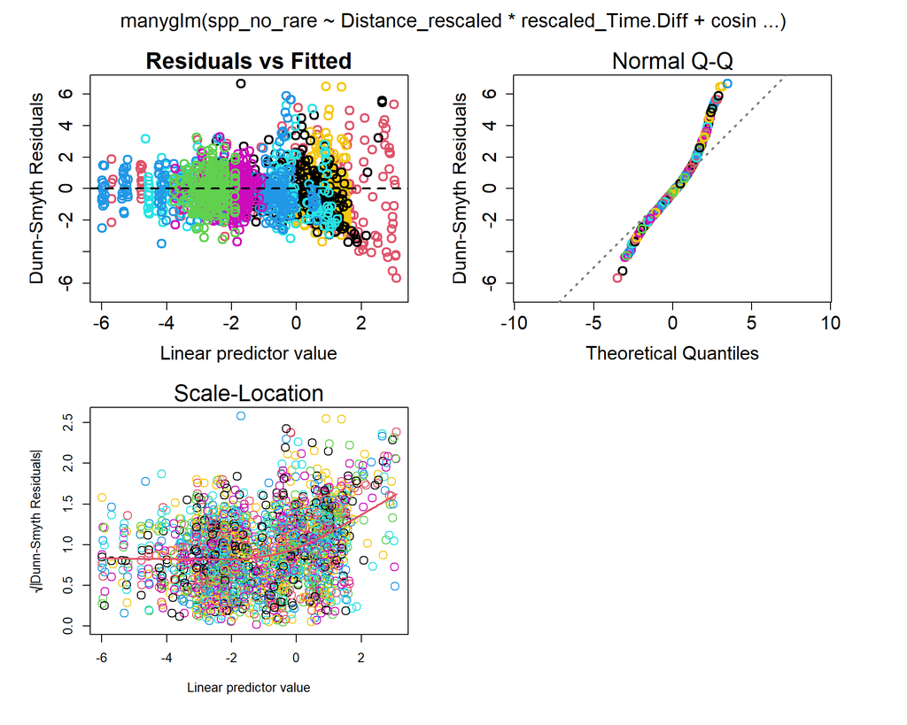

```r
plot(mva_m0.po, which=1:3)
```

```r
print("NEGATIVE BINOMIAL")
```

```
## [1] "NEGATIVE BINOMIAL"
```

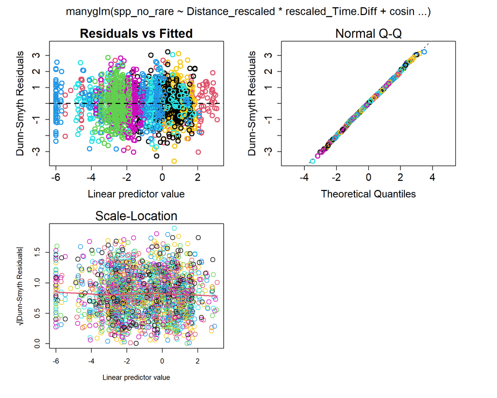

```r
plot(mva_m0.nb, which=1:3)
```

prefer negative binomial because standardized residuals are smaller.

```r
# mva_m0 <- mva_m0.po
# mva_m1 <- manyglm(formula = spp_no_rare ~ Distance_rescaled * rescaled_Time.Diff + dunes*rescaled_Time.Diff + Distance_rescaled:dunes + cos_td_rad + sin_td_rad + site, family = "poisson", data = env_data)
# aic_dt$po1 <- mva_m1$aic
mva_m0 <- mva_m0.nb
mva_m1 <- manyglm(formula = spp_no_rare ~ Distance_rescaled * rescaled_Time.Diff + cosinus_Monitoring.Time.Diff + sinus_Monitoring.Time.Diff + Transect_with_date, data = env_data)
aic_dt$nb1 <- mva_m1$aic
colMeans(aic_dt)
```

```
##       nb       po      nb1
## 590.5388 837.5866 596.8722
```

```r
mva_m2 <- manyglm(formula = spp_no_rare ~ Distance_rescaled * rescaled_Time.Diff + cosinus_Monitoring.Time.Diff + sinus_Monitoring.Time.Diff + Transect, data = env_data)
aic_dt$nb2 <- mva_m2$aic
colMeans(aic_dt)
```

```
##       nb       po      nb1      nb2
## 590.5388 837.5866 596.8722 586.2624
```

```r
mva_m3 <- manyglm(formula = spp_no_rare ~ Distance_rescaled * rescaled_Time.Diff + cosinus_Monitoring.Time.Diff + sinus_Monitoring.Time.Diff + Site, data = env_data)
aic_dt$nb3 <- mva_m2$aic
colMeans(aic_dt)
```

```
##       nb       po      nb1      nb2      nb3
## 590.5388 837.5866 596.8722 586.2624 586.2624
```

##Many GLM with site:

```r
mva_m0.nb <- manyglm(formula = spp_no_rare ~ Distance_rescaled * rescaled_Time.Diff + cosinus_Monitoring.Time.Diff + sinus_Monitoring.Time.Diff + Site, family = "negative.binomial", data = env_data)
drop1(mva_m0.nb)
```

```
## Single term deletions
##
## Model:
## spp_no_rare ~ Distance_rescaled * rescaled_Time.Diff + cosinus_Monitoring.Time.Diff +
##     sinus_Monitoring.Time.Diff + Site
##                                      Df    AIC
## <none>                                  4133.8
## cosinus_Monitoring.Time.Diff          7 4162.7
## sinus_Monitoring.Time.Diff            7 4129.7
## Site                                 28 4293.6
## Distance_rescaled:rescaled_Time.Diff  7 4141.1
```

Dropped Sin monitoring time

```r
# mva_m2 <- manyglm(formula = spp_no_rare ~ Distance_rescaled + dunes*rescaled_Time.Diff + Distance_rescaled:dunes + cos_td_rad + sin_td_rad, family = "poisson", data = env_data)
mva_m2 <- manyglm(formula = spp_no_rare ~ Distance_rescaled * rescaled_Time.Diff + cosinus_Monitoring.Time.Diff + Site, family = "negative.binomial", data = env_data)
drop1(mva_m2)
```

```
## Single term deletions
##
## Model:
## spp_no_rare ~ Distance_rescaled * rescaled_Time.Diff + cosinus_Monitoring.Time.Diff +
##     Site
##                                      Df    AIC
## <none>                                  4129.7
## cosinus_Monitoring.Time.Diff          7 4156.8
## Site                                 28 4292.4
## Distance_rescaled:rescaled_Time.Diff  7 4135.7
```

Final model includes cosin time, site and the interaction between distance from settlement and time difference.

```r
# mva_m2 <- manyglm(formula = spp_no_rare ~ Distance_rescaled + dunes + rescaled_Time.Diff + Distance_rescaled:dunes + cos_td_rad + sin_td_rad, family = "poisson", data = env_data)
# mva_m2 <- manyglm(spp_no_rare ~ Distance_rescaled * rescaled_Time.Diff + cosinus_Monitoring.Time.Diff + Site, family = "negative.binomial", data = env_data)
# drop1(mva_m2)
```

```r
# mva_m2 <- manyglm(formula = spp_no_rare ~ Distance_rescaled + dunes + rescaled_Time.Diff + Distance_rescaled:dunes + cos_td_rad + sin_td_rad, family = "poisson", data = env_data)
# mva_m2 <- manyglm(formula = spp_no_rare ~ Distance_rescaled * rescaled_Time.Diff + cosinus_Monitoring.Time.Diff + Site, family = "negative.binomial", data = env_data)
# drop1(mva_m2)
```

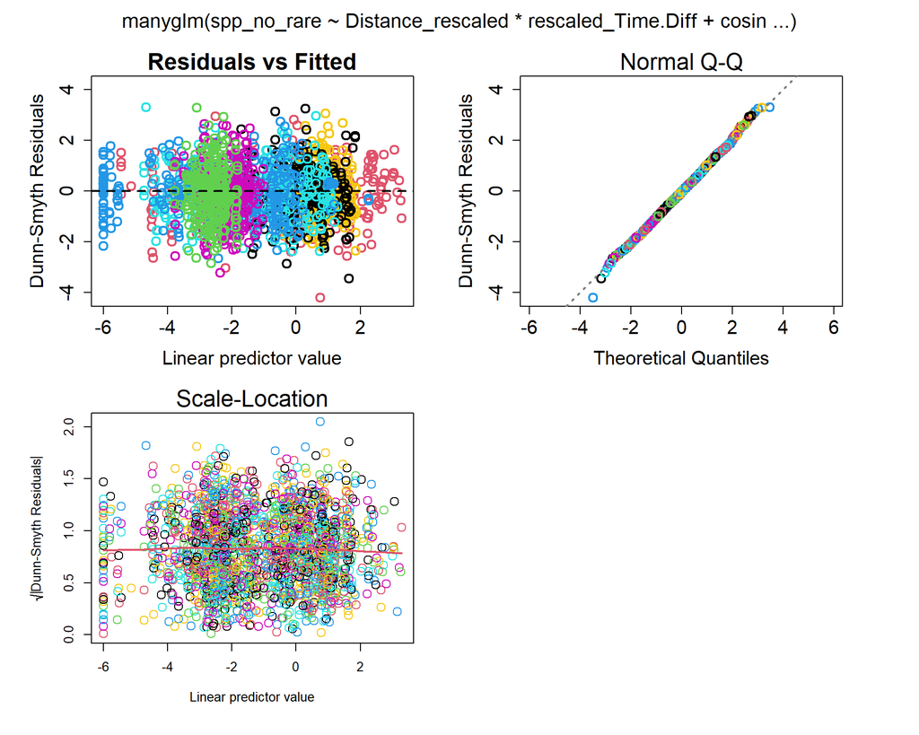

```r
plot(mva_m2, which=1:3)
```

```r
# summ_m2 <- summary(mva_m2)
# saveRDS(summ_m2, file = "../output/summ_md_zone_999iter.rds")
summ_m2 <- readRDS(file = "../output/summ_md_zone_999iter.rds")
print(summ_m2)
```

```
##
## Test statistics:
##                                      wald value Pr(>wald)
## (Intercept)                              11.708     0.001 ***
## Distance_rescaled                         2.844     0.366
## rescaled_Time.Diff                       10.298     0.001 ***
## cosinus_Monitoring.Time.Diff              6.435     0.001 ***
## SiteHar Amasa                             4.799     0.003 **
## SiteLahav                                 7.012     0.001 ***
## SiteLehavim                               8.936     0.001 ***
## SiteMirsham                               6.585     0.001 ***
## Distance_rescaled:rescaled_Time.Diff      4.488     0.014 *
## ---
## Signif. codes:  0 '***' 0.001 '**' 0.01 '*' 0.05 '.' 0.1 ' ' 1
##
## Test statistic:  19.12, p-value: 0.001
## Arguments:
##  Test statistics calculated assuming response assumed to be uncorrelated
##  P-value calculated using 999 resampling iterations via pit.trap resampling (to account for correlation in testing).
```

```r
# anov_m2.uni <- anova(mva_m2, p.uni = "adjusted")
# saveRDS(anov_m2.uni, file = "../output/anova_md_zone_999iter.rds")
anov_m2.uni <- readRDS(file = "../output/anova_md_zone_999iter.rds")
print(anov_m2.uni)
```

```
## Analysis of Deviance Table
##
## Model: spp_no_rare ~ Distance_rescaled * rescaled_Time.Diff + cosinus_Monitoring.Time.Diff + Site
##
## Multivariate test:
##                                      Res.Df Df.diff    Dev Pr(>Dev)
## (Intercept)                             280
## Distance_rescaled                       279       1   8.26    0.431
## rescaled_Time.Diff                      278       1  97.93    0.001 ***
## cosinus_Monitoring.Time.Diff            277       1  41.87    0.001 ***
## Site                                    273       4 217.63    0.001 ***
## Distance_rescaled:rescaled_Time.Diff    272       1  20.02    0.010 **
## ---
## Signif. codes:  0 '***' 0.001 '**' 0.01 '*' 0.05 '.' 0.1 ' ' 1
##
## Univariate Tests:
##                                      Canis.aureus          Gazella.gazella
##                                               Dev Pr(>Dev)             Dev
## (Intercept)
## Distance_rescaled                           7.309    0.098           0.143
## rescaled_Time.Diff                           0.62    0.753          52.311
## cosinus_Monitoring.Time.Diff                0.104    0.941          28.269
## Site                                       37.665    0.001           80.17
## Distance_rescaled:rescaled_Time.Diff       16.132    0.002           1.916
##                                               Hyaena.hyaena
##                                      Pr(>Dev)           Dev Pr(>Dev)
## (Intercept)
## Distance_rescaled                       0.992             0    0.994
## rescaled_Time.Diff                      0.001         0.583    0.753
## cosinus_Monitoring.Time.Diff            0.001           0.1    0.941
## Site                                    0.001         2.213    0.750
## Distance_rescaled:rescaled_Time.Diff    0.669         0.034    0.928
##                                      Hystrix.indica          Lepus.capensis
##                                                 Dev Pr(>Dev)            Dev
## (Intercept)
## Distance_rescaled                             0.278    0.992          0.482
## rescaled_Time.Diff                            2.348    0.413          5.071
## cosinus_Monitoring.Time.Diff                  2.923    0.465          1.416
## Site                                         45.406    0.001         44.074
## Distance_rescaled:rescaled_Time.Diff          0.751    0.910          0.334
##                                               Meles.meles
##                                      Pr(>Dev)         Dev Pr(>Dev)
## (Intercept)
## Distance_rescaled                       0.992       0.012    0.994
## rescaled_Time.Diff                      0.144       3.238    0.314
## cosinus_Monitoring.Time.Diff            0.739       0.436    0.899
## Site                                    0.001       4.192    0.750
## Distance_rescaled:rescaled_Time.Diff    0.923       0.699    0.910
##                                      Vulpes.vulpes
##                                                Dev Pr(>Dev)
## (Intercept)
## Distance_rescaled                            0.037    0.993
## rescaled_Time.Diff                          33.757    0.001
## cosinus_Monitoring.Time.Diff                 8.616    0.036
## Site                                         3.909    0.750
## Distance_rescaled:rescaled_Time.Diff         0.155    0.928
## Arguments:
##  Test statistics calculated assuming uncorrelated response (for faster computation)
## P-value calculated using 999 iterations via PIT-trap resampling.
```

**Multivariate test shows that cosin monitoring time, Site, time difference and interaction between distance from settlement and time difference are statistically significant**

```r
coefp <- merge(data.table(t(coef(mva_m2)/log(2)),keep.rownames=TRUE), data.table(t(anov_m2.uni$uni.p), keep.rownames = TRUE), by = "rn") # coefficients are exponentiated because the link function used for poisson is log -> above 1 is positive and below 1 is negative
# add total species abundance
coefp <- merge(coefp,as.data.table(colSums(spp_no_rare),keep.rownames = TRUE), by.x = "rn", by.y = "V1")

colnames(coefp) <- c("SciName","Intercept.coef","Distance.coef","Time_diff.coef","Cosin_time.coef","Site_Har_Amasa.coef.coef","Site_Lahav.coef","Site_Lehavim.coef","Site_Mirsham.coef","Distance_time.coef", "Intercept.p","Distance.p","Time_diff.p","Cosin_time.p","Site.p","Distance_time.p","species_abundance")

write.csv(coefp, "../output/sfar/coefficients_MD_trans_zone.csv")

print(coefp)
```

```
##            SciName Intercept.coef Distance.coef Time_diff.coef Cosin_time.coef
## 1:    Canis.aureus      1.0426105   -0.49842766     -0.2547011      -0.7703213
## 2: Gazella.gazella      1.0806655   -0.03783560      1.4691821      -0.8122920
## 3:   Hyaena.hyaena     -4.1444314   -0.11357307      0.3509670       0.2731952
## 4:  Hystrix.indica     -7.5445021   -0.81949108     -0.2388161       3.4396769
## 5:  Lepus.capensis     -0.9643288    0.55167154      0.8515688       0.4104079
## 6:     Meles.meles     -4.2475336   -0.02100113      0.6439979       0.3446737
## 7:   Vulpes.vulpes      1.1132860    0.32760272      0.7923119       0.5083757
##    Site_Har_Amasa.coef.coef Site_Lahav.coef Site_Lehavim.coef Site_Mirsham.coef
## 1:               -1.6322308       0.3809060        -2.7546359        -1.2060801
## 2:               -0.9964718      -6.4625798        -3.8012093         0.0947497
## 3:                0.8451841       0.2244599        -0.7139241         0.5949948
## 4:                2.7516229       4.3285701         3.8180456         8.5896454
## 5:               -0.1058152      -4.8690602         1.7640321        -3.1111254
## 6:                1.1492627       1.0279397         1.4993780         1.5967657
```

[output cut: 17 more lines]

```r
#### Canis aureus####

Canis.aureus <- spp_no_rare[,"Canis.aureus"]
glm.Canis.aureus <- glm.nb(formula = Canis.aureus ~ Distance_rescaled * rescaled_Time.Diff + cosinus_Monitoring.Time.Diff + Site, data = env_data)
coef(glm.Canis.aureus)
```

```
##                          (Intercept)                    Distance_rescaled
##                            0.7226852                           -0.3454709
##                   rescaled_Time.Diff         cosinus_Monitoring.Time.Diff
##                           -0.1765497                           -0.5339577
##                        SiteHar Amasa                            SiteLahav
##                           -1.1313627                            0.2640154
##                          SiteLehavim                          SiteMirsham
##                           -1.9093470                           -0.8359891
## Distance_rescaled:rescaled_Time.Diff
##                           -1.0069294
```

```r
coef(mva_m2)
```

```
##                                      Canis.aureus Gazella.gazella Hyaena.hyaena
## (Intercept)                             0.7226825      0.74906022   -2.87270092
## Distance_rescaled                      -0.3454837     -0.02622564   -0.07872285
## rescaled_Time.Diff                     -0.1765454      1.01835942    0.24327181
## cosinus_Monitoring.Time.Diff           -0.5339460     -0.56303790    0.18936451
## SiteHar Amasa                          -1.1313762     -0.69070165    0.58583696
## SiteLahav                               0.2640240     -4.47951898    0.15558375
## SiteLehavim                            -1.9093681     -2.63479750   -0.49485445
## SiteMirsham                            -0.8359910      0.06567549    0.41241896
## Distance_rescaled:rescaled_Time.Diff   -1.0069533     -0.36920755    0.08898667
##                                      Hystrix.indica Lepus.capensis Meles.meles
## (Intercept)                              -5.2294503    -0.66842180 -2.94416591
## Distance_rescaled                        -0.5680279     0.38238957 -0.01455687
## rescaled_Time.Diff                       -0.1655347     0.59026253  0.44638532
## cosinus_Monitoring.Time.Diff              2.3842023     0.28447305  0.23890958
## SiteHar Amasa                             1.9072796    -0.07334553  0.79660820
## SiteLahav                                 3.0003362    -3.37497537  0.71251350
## SiteLehavim                               2.6464676     1.22273387  1.03928967
## SiteMirsham                               5.9538885    -2.15646780  1.10679362
## Distance_rescaled:rescaled_Time.Diff      0.4173575     0.25635910  0.30505705
##                                      Vulpes.vulpes
## (Intercept)                             0.77167103
## Distance_rescaled                       0.22707690
## rescaled_Time.Diff                      0.54918876
## cosinus_Monitoring.Time.Diff            0.35237916
## SiteHar Amasa                           0.07714693
## SiteLahav                              -0.20611633
## SiteLehavim                            -0.19675301
## SiteMirsham                            -0.26777162
## Distance_rescaled:rescaled_Time.Diff   -0.06723827
```

```r
print(sum(Canis.aureus))
```

```
## [1] 467
```

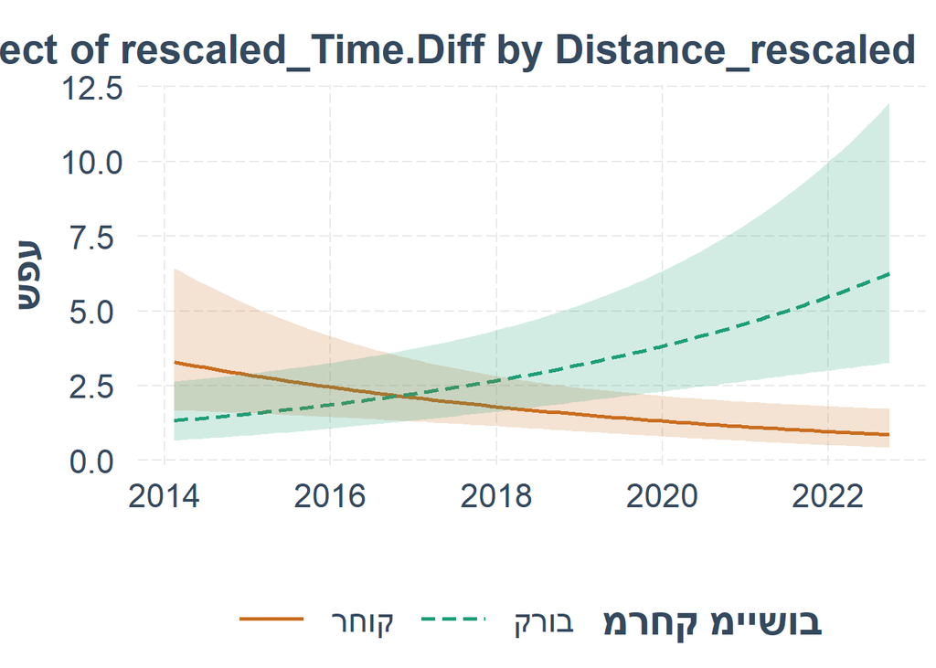

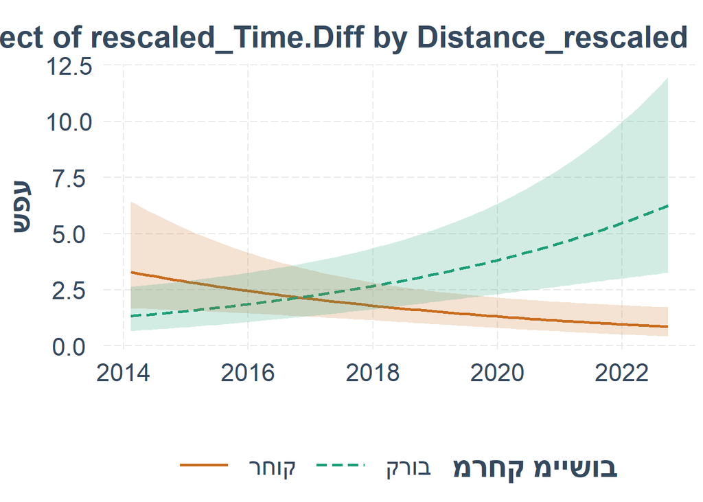

```r
plot_model_interaction(P.anal = env_data, m = glm.Canis.aureus, eff2plot = "rescaled_Time.Diff", modvar2plot = "Distance_rescaled", plot_points=FALSE, plot_residuals=FALSE, export_plot=TRUE, ylabel = NULL, fontname = "Almoni ML v5 AAA", fontsize=22, pdf_width=160, outpath = "../output/sfar/", legend_position = "bottom")
```

```r
# interact_plot(model = glm.Canis.aureus, data=env_data, pred = rescaled_Time.Diff, modx = Distance_rescaled, modx.values = "plus-minus", partial.residuals = F, jitter = c(0.2), point.size = 3, rug = F, point.shape = F, interval = T, colors = "Dark2") + scale_x_continuous(breaks=c(-1.233466888,-0.601840099,0.028922631,0.66054942,1.291312151), labels=c("June 2014", "June 2016", "June 2018", "June 2020", "June 2022"), name = "Time")

#Testing whether trends and means are different from zero

#Calculate mean and sd of distance
sd_distance <- sd(env_data$Distance_rescaled)
print(sd_distance)
```

```
## [1] 0.5278765
```

```r
mean_distance <- mean(env_data$Distance_rescaled)
print(mean_distance)
```

```
## [1] -0.2131719
```

```r
#calculate +/1 1 SD
small_distance <- mean_distance - sd_distance
large_distance <- mean_distance + sd_distance

#Test whether temporal trend is different from zero
mm_rescaled_time <- emtrends(glm.Canis.aureus, specs = "Distance_rescaled", var = "rescaled_Time.Diff", type = "response", at = list(Distance_rescaled = c(small_distance,large_distance)))
print(mm_rescaled_time)
```

```
##  Distance_rescaled rescaled_Time.Diff.trend    SE  df asymp.LCL asymp.UCL
##             -0.741                    0.570 0.171 Inf     0.235     0.904
##              0.315                   -0.493 0.192 Inf    -0.869    -0.118
##
## Results are averaged over the levels of: Site
## Confidence level used: 0.95
```

```r
test_results_mm_rescaled_time <- test(mm_rescaled_time, null = 0, adjust = "fdr")
print(test_results_mm_rescaled_time)
```

```
##  Distance_rescaled rescaled_Time.Diff.trend    SE  df z.ratio p.value
##             -0.741                    0.570 0.171 Inf   3.335  0.0017
##              0.315                   -0.493 0.192 Inf  -2.576  0.0100
##
## Results are averaged over the levels of: Site
## P value adjustment: fdr method for 2 tests
```

```r
#Testing whether abundance is higher near or far from settlements
pairwise_distance <- emmeans(object = glm.Canis.aureus, ~Distance_rescaled*rescaled_Time.Diff, at = list(Distance_rescaled = c(small_distance,large_distance)))
test_results_distance <- test(pairs(pairwise_distance, by="rescaled_Time.Diff"), by=NULL, adjust="fdr")
print(test_results_distance)
```

```
##  contrast
##  (Distance_rescaled-0.741048431885884) - Distance_rescaled0.31470454181471
##  rescaled_Time.Diff estimate    SE  df z.ratio p.value
##                0.34    0.727 0.246 Inf   2.952  0.0032
##
## Results are averaged over the levels of: Site
## Results are given on the log (not the response) scale.
```

On average over time, Jackal abundance is significantly higher near settlements (p = 0.003)

```r
#### Gazella gazella####

Gazella.gazella <- spp_no_rare[,"Gazella.gazella"]
glm.Gazella.gazella <- glm.nb(formula = Gazella.gazella ~ Distance_rescaled + rescaled_Time.Diff + cosinus_Monitoring.Time.Diff + Site, data = env_data)
coef(glm.Gazella.gazella)
```

```
##                  (Intercept)            Distance_rescaled
##                    0.7496189                   -0.1220151
##           rescaled_Time.Diff cosinus_Monitoring.Time.Diff
##                    1.0639549                   -0.5311252
##                SiteHar Amasa                    SiteLahav
##                   -0.6811244                   -4.4244071
##                  SiteLehavim                  SiteMirsham
##                   -2.5844055                    0.1011102
```

```r
coef(mva_m2)
```

```
##                                      Canis.aureus Gazella.gazella Hyaena.hyaena
## (Intercept)                             0.7226825      0.74906022   -2.87270092
## Distance_rescaled                      -0.3454837     -0.02622564   -0.07872285
## rescaled_Time.Diff                     -0.1765454      1.01835942    0.24327181
## cosinus_Monitoring.Time.Diff           -0.5339460     -0.56303790    0.18936451
## SiteHar Amasa                          -1.1313762     -0.69070165    0.58583696
## SiteLahav                               0.2640240     -4.47951898    0.15558375
## SiteLehavim                            -1.9093681     -2.63479750   -0.49485445
## SiteMirsham                            -0.8359910      0.06567549    0.41241896
## Distance_rescaled:rescaled_Time.Diff   -1.0069533     -0.36920755    0.08898667
##                                      Hystrix.indica Lepus.capensis Meles.meles
## (Intercept)                              -5.2294503    -0.66842180 -2.94416591
## Distance_rescaled                        -0.5680279     0.38238957 -0.01455687
## rescaled_Time.Diff                       -0.1655347     0.59026253  0.44638532
## cosinus_Monitoring.Time.Diff              2.3842023     0.28447305  0.23890958
## SiteHar Amasa                             1.9072796    -0.07334553  0.79660820
## SiteLahav                                 3.0003362    -3.37497537  0.71251350
## SiteLehavim                               2.6464676     1.22273387  1.03928967
## SiteMirsham                               5.9538885    -2.15646780  1.10679362
## Distance_rescaled:rescaled_Time.Diff      0.4173575     0.25635910  0.30505705
##                                      Vulpes.vulpes
## (Intercept)                             0.77167103
## Distance_rescaled                       0.22707690
## rescaled_Time.Diff                      0.54918876
## cosinus_Monitoring.Time.Diff            0.35237916
## SiteHar Amasa                           0.07714693
## SiteLahav                              -0.20611633
## SiteLehavim                            -0.19675301
## SiteMirsham                            -0.26777162
## Distance_rescaled:rescaled_Time.Diff   -0.06723827
```

```r
print(sum(Gazella.gazella))
```

```
## [1] 940
```

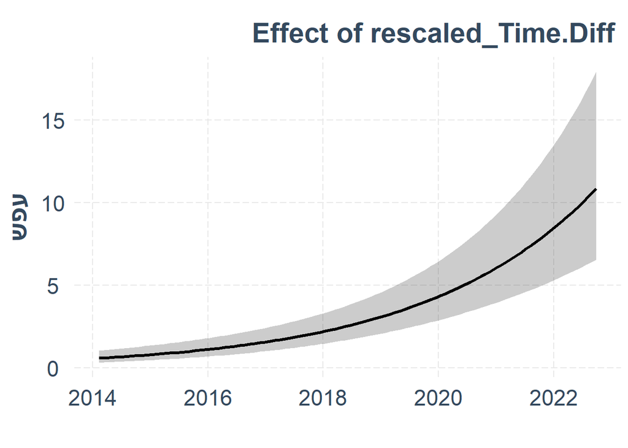

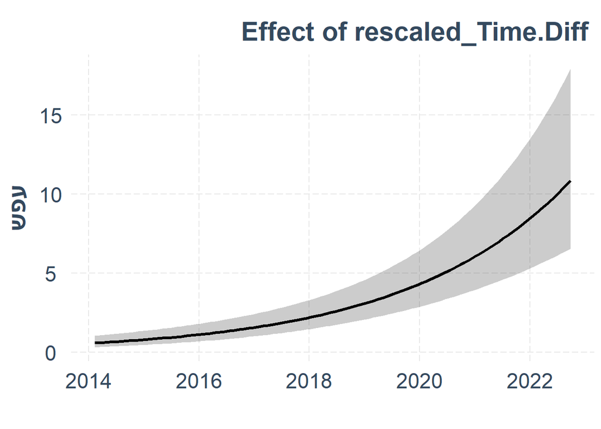

```r
source("../functions/plot_model_effect_mammals.R")

plot_model_effect(P.anal = env_data, m = glm.Gazella.gazella, eff2plot = "rescaled_Time.Diff", plot_points=FALSE, plot_residuals=FALSE, export_plot=TRUE, ylabel = NULL, fontname = "Almoni ML v5 AAA", fontsize=22, pdf_width=160, outpath = "../output/sfar/")
```

```r
# effect_plot(model = glm.Gazella.gazella, data=env_data, pred = rescaled_Time.Diff, interval = T, plot.points = F, jitter = c(0.1,0), partial.residuals = F, colors = "Qual1") + ylim(0,15) + scale_x_continuous(breaks=c(-1.233466888,-0.601840099,0.028922631,0.66054942,1.291312151), labels=c("June 2014", "June 2016", "June 2018", "June 2020", "June 2022"), name = "Time")

#### Vulpes vulpes####

Vulpes.vulpes <- spp_no_rare[,"Vulpes.vulpes"]
glm.Vulpes.vulpes <- glm.nb(formula = Vulpes.vulpes ~ Distance_rescaled + rescaled_Time.Diff + cosinus_Monitoring.Time.Diff + Site, data = env_data)
coef(glm.Vulpes.vulpes)
```

```
##                  (Intercept)            Distance_rescaled
##                   0.76602777                   0.21065333
##           rescaled_Time.Diff cosinus_Monitoring.Time.Diff
##                   0.56631374                   0.36083191
##                SiteHar Amasa                    SiteLahav
##                   0.07968601                  -0.20764925
##                  SiteLehavim                  SiteMirsham
##                  -0.19653653                  -0.25479826
```

```r
coef(mva_m2)
```

```
##                                      Canis.aureus Gazella.gazella Hyaena.hyaena
## (Intercept)                             0.7226825      0.74906022   -2.87270092
## Distance_rescaled                      -0.3454837     -0.02622564   -0.07872285
## rescaled_Time.Diff                     -0.1765454      1.01835942    0.24327181
## cosinus_Monitoring.Time.Diff           -0.5339460     -0.56303790    0.18936451
## SiteHar Amasa                          -1.1313762     -0.69070165    0.58583696
## SiteLahav                               0.2640240     -4.47951898    0.15558375
## SiteLehavim                            -1.9093681     -2.63479750   -0.49485445
## SiteMirsham                            -0.8359910      0.06567549    0.41241896
## Distance_rescaled:rescaled_Time.Diff   -1.0069533     -0.36920755    0.08898667
##                                      Hystrix.indica Lepus.capensis Meles.meles
## (Intercept)                              -5.2294503    -0.66842180 -2.94416591
## Distance_rescaled                        -0.5680279     0.38238957 -0.01455687
## rescaled_Time.Diff                       -0.1655347     0.59026253  0.44638532
## cosinus_Monitoring.Time.Diff              2.3842023     0.28447305  0.23890958
## SiteHar Amasa                             1.9072796    -0.07334553  0.79660820
## SiteLahav                                 3.0003362    -3.37497537  0.71251350
## SiteLehavim                               2.6464676     1.22273387  1.03928967
## SiteMirsham                               5.9538885    -2.15646780  1.10679362
## Distance_rescaled:rescaled_Time.Diff      0.4173575     0.25635910  0.30505705
##                                      Vulpes.vulpes
## (Intercept)                             0.77167103
## Distance_rescaled                       0.22707690
## rescaled_Time.Diff                      0.54918876
## cosinus_Monitoring.Time.Diff            0.35237916
## SiteHar Amasa                           0.07714693
## SiteLahav                              -0.20611633
## SiteLehavim                            -0.19675301
## SiteMirsham                            -0.26777162
## Distance_rescaled:rescaled_Time.Diff   -0.06723827
```

```r
print(sum(Vulpes.vulpes))
```

```
## [1] 708
```

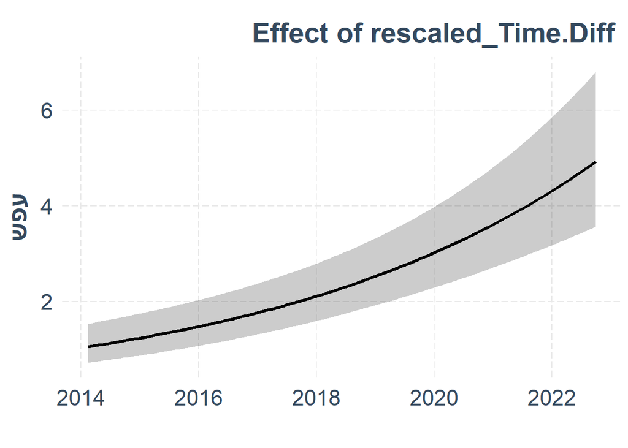

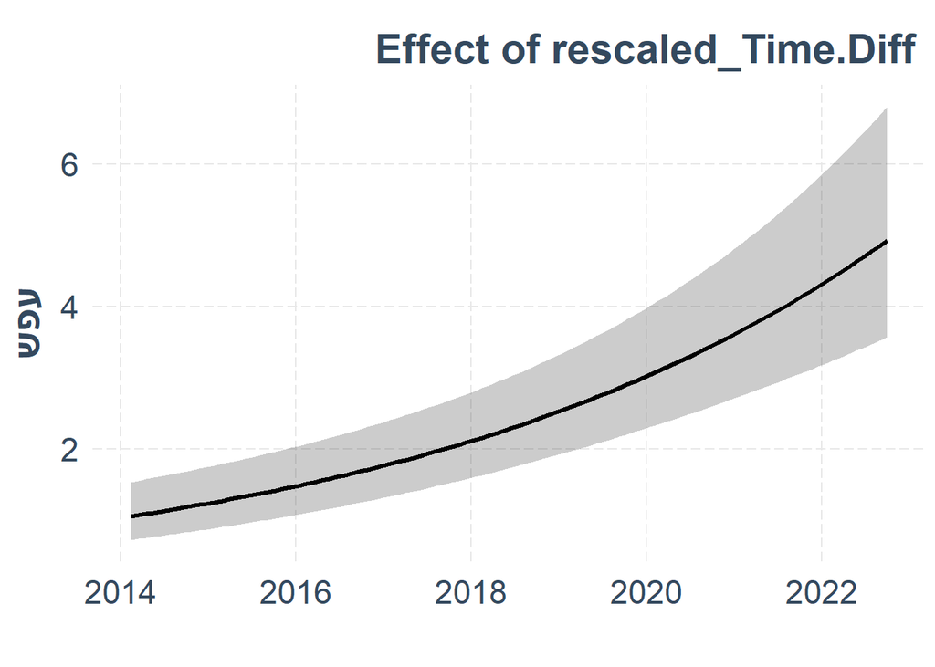

```r
plot_model_effect(P.anal = env_data, m = glm.Vulpes.vulpes, eff2plot = "rescaled_Time.Diff", plot_points=FALSE, plot_residuals=FALSE, export_plot=TRUE, ylabel = NULL, fontname = "Almoni ML v5 AAA", fontsize=22, pdf_width=160, outpath = "../output/sfar/")
```

```r
# effect_plot(model = glm.Vulpes.vulpes, data=env_data, pred = rescaled_Time.Diff, interval = T, plot.points = F, jitter = c(0.1,0), partial.residuals = F, colors = "Qual1") + ylim(0,10) + scale_x_continuous(breaks=c(-1.233466888,-0.601840099,0.028922631,0.66054942,1.291312151), labels=c("June 2014", "June 2016", "June 2018", "June 2020", "June 2022"), name = "Time")
```

n = 281 (total number of cameras)

total abundance = 2454 (7 species), total abundance without rare species is the same (all rare species had zero observations)